# Boxplots and Violin Plots with Mirrored Axis Transfrom of Fold Change (MAD-FC)

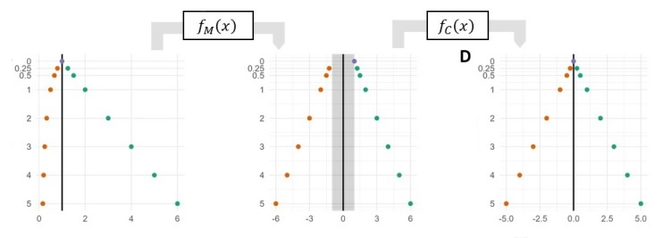

# 1 Introduction

B. A. Corliss, Y. Wang, F. P. Driscoll, H. Shakeri, P. E. Bourne, MAD-FC: A Fold Change Visualization with Readability, Proportionality, and Symmetry (2023), doi:10.48550/arXiv.2303.10829.

## 1.1 Dataset and Code Sources

**Dataset Availability:** This vignette uses a dataset from the RTCGA and RTCGA.mRNA packages that is included with DESeq2.

**Code Reference:** This tutorial uses code from the [introductory vignette](https://bioconductor.org/packages/devel/bioc/vignettes/DESeq2/inst/doc/DESeq2.html) for DESeq2. “Analyzing RNA-seq data with DESeq2” by Michael I. Love, Simon Anders, and Wolfgang Huber.

## 1.2 Package Dependencies

**Primary Packages:** *tidyverse, cowplot, BiocManager, ggpubr*

**Supporting Packages:** *RTCGA, RTCGA.mRNA*

The MAD-FC source file is also required (mirrored_axis_distortion.R)

```r
# Install required Base Packages
base_packages <- c("tidyverse", "cowplot","BiocManager","ggpubr")
install.packages(setdiff(base_packages, rownames(installed.packages())))
# Install required Bioconductor Packages
biocm_packages <- c("RTCGA", "RTCGA.mRNA")
bioc_installs <- setdiff(biocm_packages, rownames(installed.packages()))
if (length(bioc_installs)) {BiocManager::install(bioc_installs) }

# Load base packages
lapply(base_packages, library, character.only = TRUE)
# Load Bioconductor packages packages
lapply(biocm_packages, library, character.only = TRUE)
source(paste0(dirname(getwd()), "/R/mirrored_axis_distortion.R"))
```

# 2 Data Analysis

We processing the data with the following steps:

1. Combine three different datasets from RTCGA and extract expression from five genes.
2. Remove “.mRNA from the column that labels dataset source
3. Convert the data set from wide format (column for each gene) to long format
4. Calculate fold change value from log fold change measurements
5. Calculated MAD-FC fold changes based on fold change measurements.

```r
# Extract expression for 5 genes: GATA3, PTEN, XBP1, ESR1 and MUC1
# From the BRCA.mRNA, OV.mRNA, LUSC.mRNA datasets
expr <- expressionsTCGA(BRCA.mRNA, OV.mRNA, LUSC.mRNA,
                        extract.cols = c("GATA3", "PTEN", "XBP1","ESR1", "MUC1"))
expr$dataset <- gsub(pattern = ".mRNA", replacement = "",  expr$dataset)

# Convert dataframe of RNA expresison from wide to long format
df_exp <- expr %>% pivot_longer(cols = !c(bcr_patient_barcode, dataset), names_to = "Gene", values_to = "log2_fc")
df_exp$fc <- 2^df_exp$log2_fc
df_exp$mad_fc <- contract1(fc_to_mfc(df_exp$fc))
head(df_exp)
```

```
## # A tibble: 6 × 6
##   bcr_patient_barcode          dataset Gene  log2_fc    fc mad_fc
##   <chr>                        <chr>   <chr>   <dbl> <dbl>  <dbl>
## 1 TCGA-A1-A0SD-01A-11R-A115-07 BRCA    GATA3    2.87  7.31   6.31
## 2 TCGA-A1-A0SD-01A-11R-A115-07 BRCA    PTEN     1.36  2.57   1.57
## 3 TCGA-A1-A0SD-01A-11R-A115-07 BRCA    XBP1     2.98  7.91   6.91
## 4 TCGA-A1-A0SD-01A-11R-A115-07 BRCA    ESR1     3.08  8.48   7.48
## 5 TCGA-A1-A0SD-01A-11R-A115-07 BRCA    MUC1     1.65  3.14   2.14
## 6 TCGA-A1-A0SE-01A-11R-A084-07 BRCA    GATA3    2.17  4.49   3.49
```

# 3 Visualization

## 3.1 Boxplots

We now will visualize the same dataset with a boxplot where fold changes are linear, log2, and MAD-FC transformed. Each type of transform has unique characteristics for how it displays the fold change values.

### 3.1.1 Linear Boxplot

We first produce a boxplot where fold changes are mapped to a linear scale (raw fold change units, y-axis). Notice that with this plot, negative fold changes are compressed between [0,1) and positive fold changes are between (1,inf). This limits the linear plot’s usefulness in comparing the magnitude of the positive and negative fold change values.

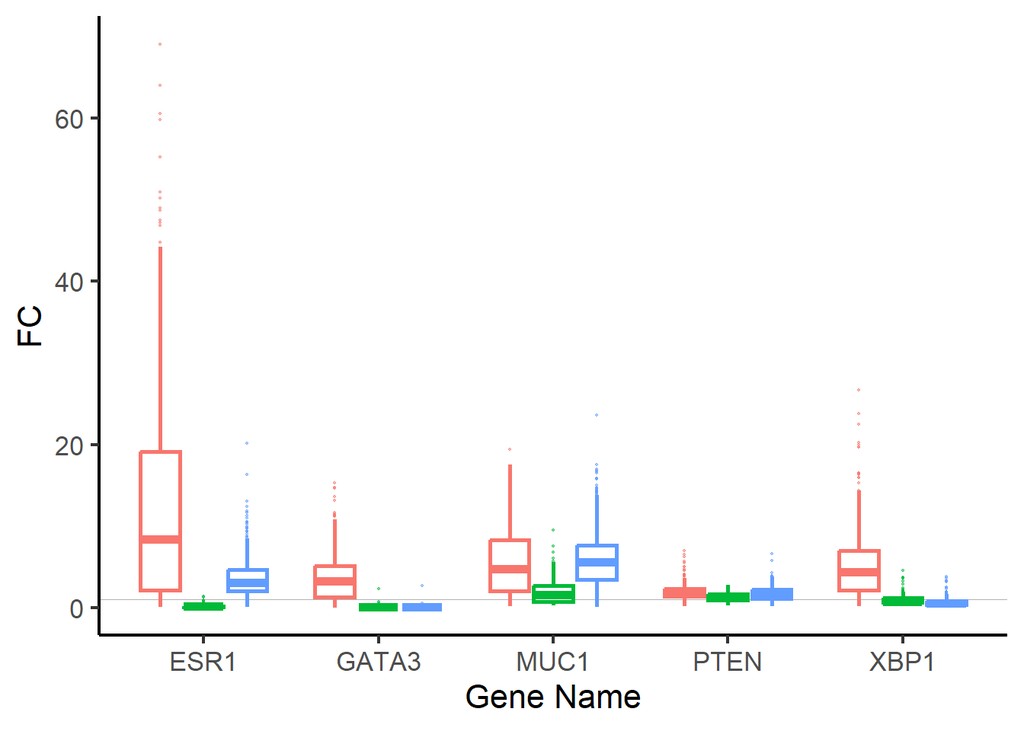

```r
# Fold Change Linear Plot
# Linear FC Plot
g1 <- ggplot(data = df_exp, aes(x = Gene, y = fc, color = dataset)) +
  geom_hline(yintercept = 1, size = .3, color = "grey70") +
  geom_boxplot(size =1, outlier.size = .3,outlier.alpha = 0.5) +
  ylab("FC") + xlab("Gene Name") +
  theme_classic(base_size = 16) +
  theme(panel.grid.minor = element_blank(),legend.position = "none")
g1
```

### 3.1.2 Log Boxplot

Next we produce a boxplot of the same data where fold changes are mapped to a log2 scale. Log plots exhibit symmetry between positive and negative fold changes, allowing them to be compared based on their relative position to zero on the log scale (the point of no change). However, the non-linearity of the log transform makes it difficult to compare the magnitude among collections of positive fold change data points and separately, negative fold changes. It is also difficult to recover the original fold change value before the log transform.

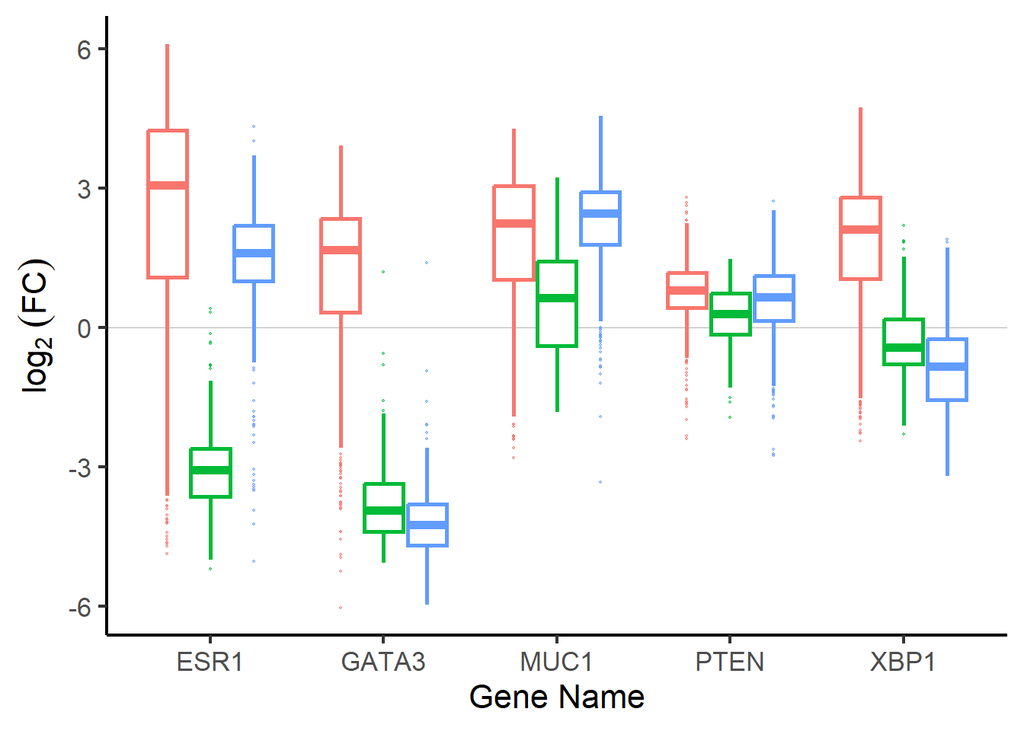

```r
# Log FC Plot
g2 <- ggplot(data = df_exp, aes(x = Gene, y = log2_fc, color = dataset)) +
  geom_hline(yintercept = 0, size = .3, color = "grey70") +
  geom_boxplot(size =1, outlier.size = .3,outlier.alpha = 0.5) +
  ylab(expression(log[2]~(FC))) + xlab("Gene Name") +
  theme_classic(base_size = 16) +
  theme(panel.grid.minor = element_blank(),legend.position = "none")
g2
```

### 3.1.3 MAD Boxplot

To create a MAD plot, first create a linear plot like above, and then call the function. gg_rev_axis_mfc(gg, axes, num_format) Where *gg* is the ggplot object, *axis* is the axis to be transformed, and *num_format* is the format used for the plot tick labels. This function extracts the axis labels from the gg plot object and reverses the MAD-FC transform to display the original FC units.

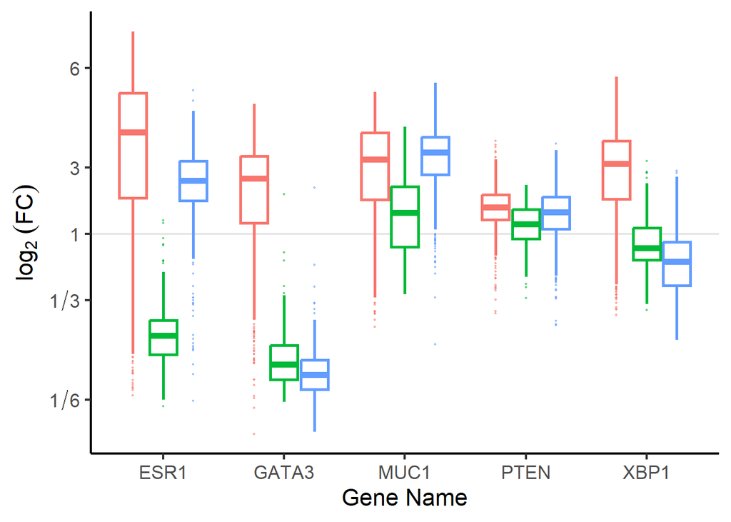

```r
# MAD FC Plot
g3 <- ggplot(data = df_exp, aes(x = Gene, y = mad_fc, color = dataset)) +
  geom_hline(yintercept = 1, size = .3, color = "grey70") +
  geom_boxplot(size =1, outlier.size = .3,outlier.alpha = 0.5) +
  scale_y_continuous(breaks = seq(-70,70,10),
                     labels = seq(-70,70,10)) +
  ylab("FC") + xlab("Gene Name") +
  theme_classic(base_size = 16) +
  theme(panel.grid.minor = element_blank(),legend.position = "none")

g3 <- gg_revaxis_mfc(g2,'y', num_format = "fraction")
g3
```

## 3.2 Violin Plots

We now will visualize the same dataset with a violin plot where fold changes are linear, log2, and MAD-FC transformed. Each type of transform has unique characteristics for how it displays the fold change values.

### 3.2.1 Linear Violin Plot

We first produce a violin plot where fold changes are mapped to a linear scale (raw fold change units, y-axis). Notice that with this plot, negative fold changes are compressed between [0,1) and positive fold changes are between (1,inf). This limits the linear plot’s usefulness in comparing the magnitude of the positive and negative fold change values.

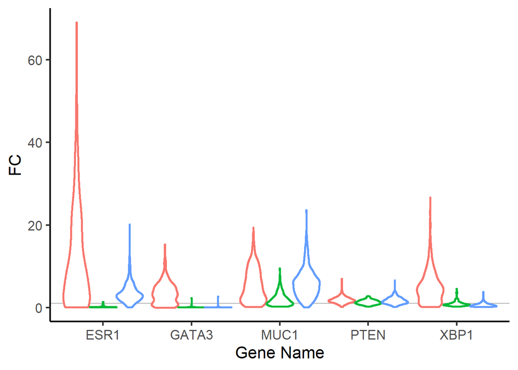

```r
# Linear Plot
g1 <- ggplot(data = df_exp, aes(x = Gene, y = fc, color = dataset)) +
  geom_hline(yintercept = 1, color = "grey70") +
  geom_violin(scale = "width", size = 1) +
  ylab("FC") + xlab("Gene Name") +
  theme_classic(base_size = 16) +
  theme(panel.grid.minor = element_blank(),legend.position = "none")
g1
```

### 3.2.2 Log Violin Plot

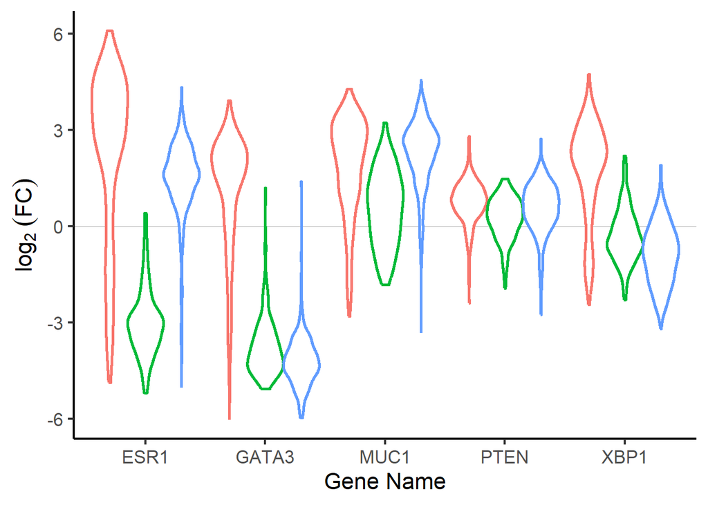

```r
# Log Plot
g2 <- ggplot(data = df_exp, aes(x = Gene, y = log2_fc, color = dataset)) +
  geom_hline(yintercept = 0, size = .3, color = "grey70") +
  geom_violin(scale = "width", size =1) +
  ylab(expression(log[2]~(FC))) + xlab("Gene Name") +
  theme_classic(base_size = 16) +
  theme(panel.grid.minor = element_blank(),legend.position = "none")
g2
```

### 3.2.3 MAD Violin Plot

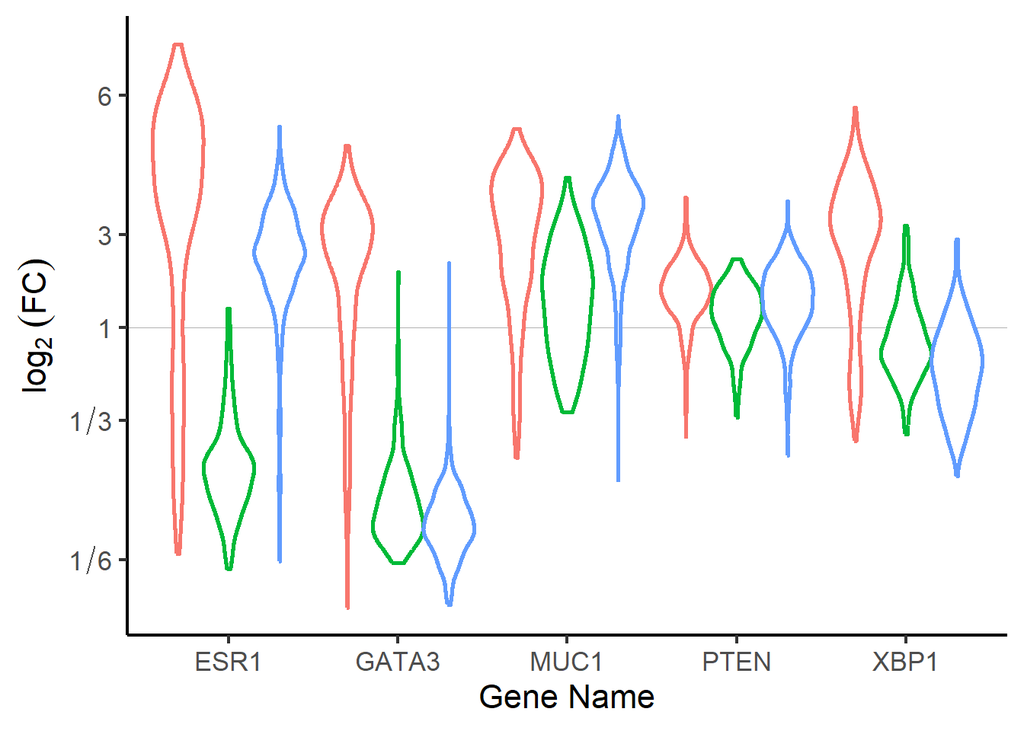

```r
# MAD-FC Plot
g3 <- ggplot(data = df_exp, aes(x = Gene, y = mad_fc, color = dataset)) +
  geom_hline(yintercept = 1, color = "grey70") +
  geom_violin(scale = "width", size = 1) +
  scale_y_continuous(breaks = seq(-60,60,20),
                     labels = seq(-60,60,20)) +
  ylab("FC") + xlab("Gene Name") +
  theme_classic(base_size = 8) +
  theme(panel.grid.minor = element_blank(),legend.position = "none")

g3 <- gg_revaxis_mfc(g2,'y', num_format = "fraction")
g3
```

Bruce Corliss, 10/16/2023